# 06_Davis_Shannon_2018

Shannon Davis

October 22, 2018

# COrrelation W&S chapter 16

## 15

### a. Display the assocation between the two varibles in a scatter plot

```r
#get data
brain <- read_csv("../Data/chap16q15LanguageGreyMatter.csv")
head(brain)
```

```
## # A tibble: 6 x 2
##   proficiency greymatter
##         <dbl>      <dbl>
## 1        0.26     -0.07
## 2        0.44     -0.08
## 3        0.89     -0.008
## 4        1.26     -0.009
## 5        1.69     -0.023
## 6        1.97     -0.009
```

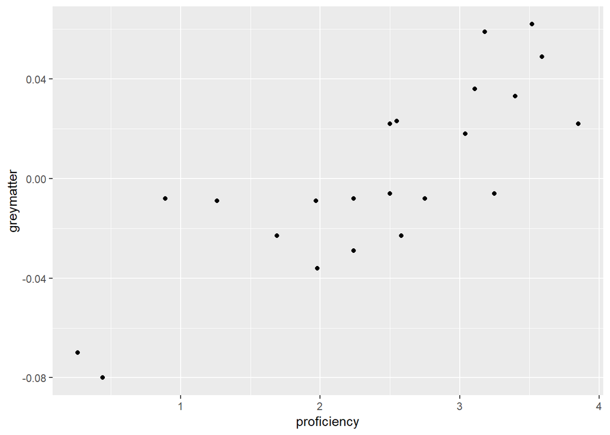

```r
#plot data
ggplot(data = brain,
       mapping = aes(x = proficiency, y = greymatter))+
  geom_point()
```

### b. Calculate the correlation between second language profiency and gray-matter density

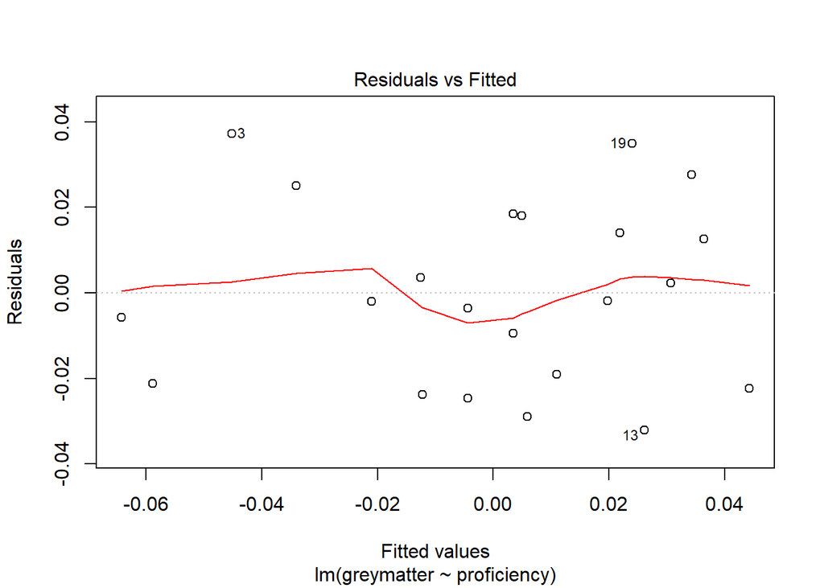

```r
#lm of brain
brain_mod <- lm(greymatter~proficiency, data = brain)

#plots to check the relationship of greymatter and proficiency
plot(brain_mod, which = 1) #residual v fitted
```

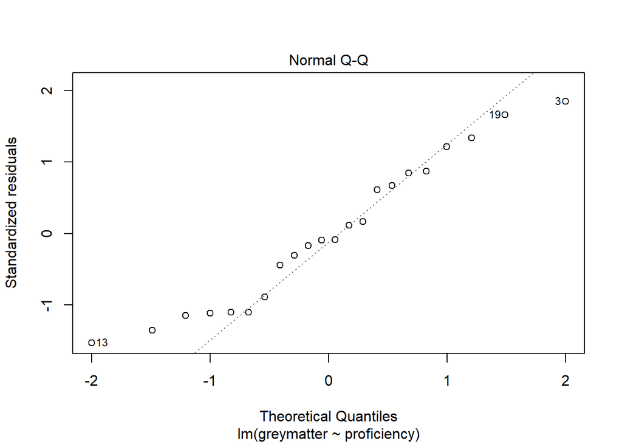

```r
plot(brain_mod, which = 2)# qq plot
```

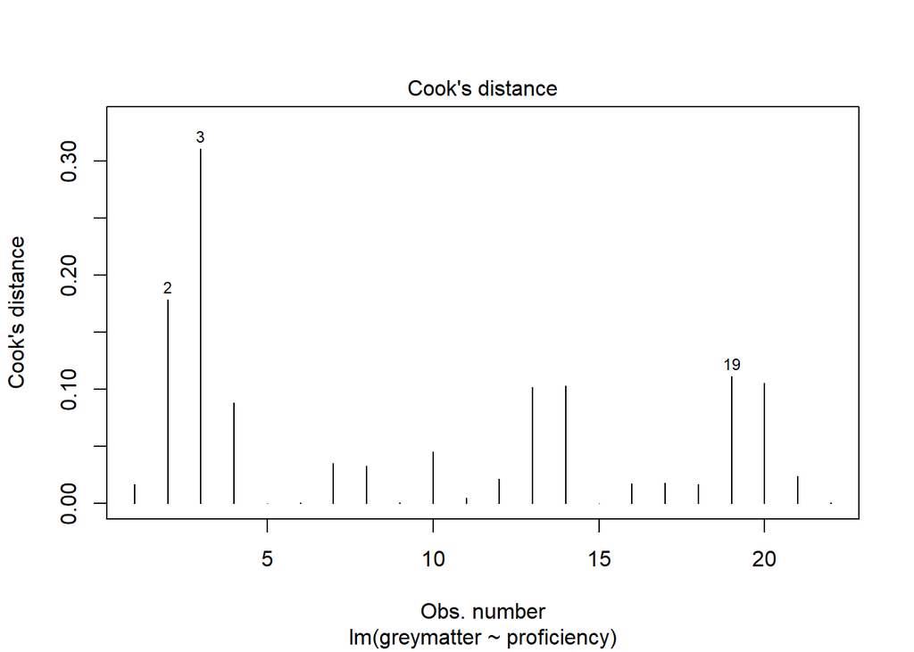

```r
plot(brain_mod, which = 4) #cooks distance
```

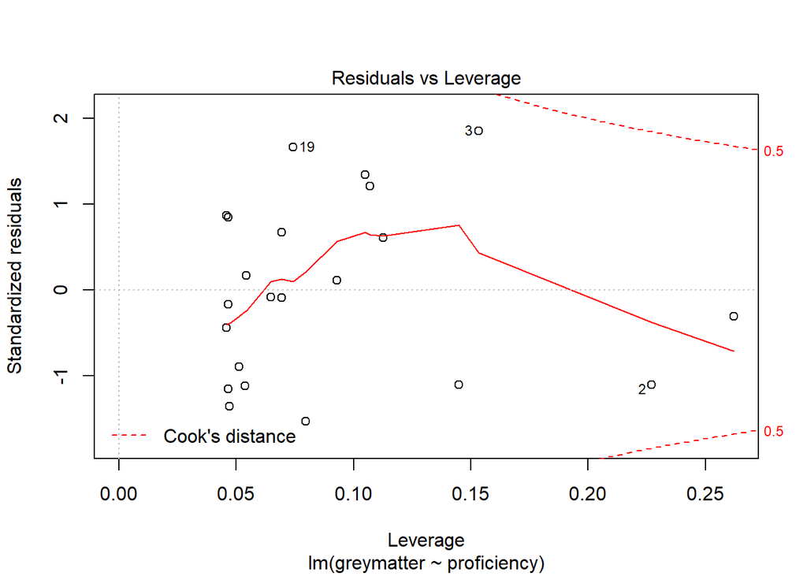

```r
plot(brain_mod, which = 5) #leverage v residual
```

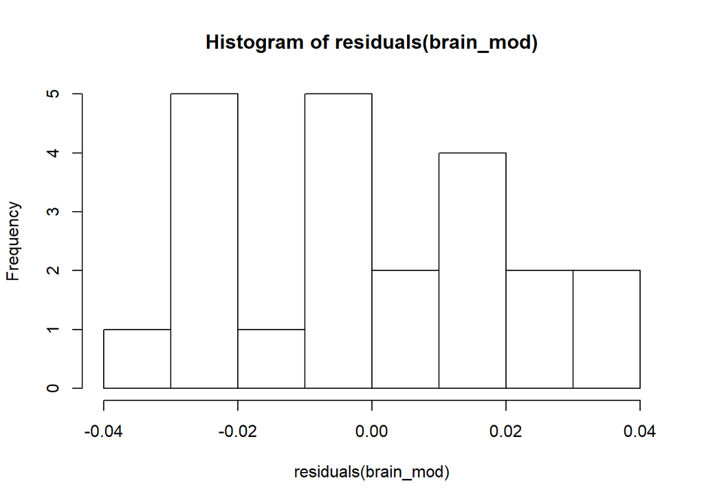

```r
hist(residuals(brain_mod))
```

```r
#summary to look at the fit
summary(brain_mod) %>% broom::glance()
```

```
## # A tibble: 1 x 6
##   r.squared adj.r.squared  sigma statistic    p.value    df
## *     <dbl>         <dbl>  <dbl>     <dbl>      <dbl> <int>
## 1     0.670         0.653 0.0218      40.5 0.00000326     2
```

### c. Test the null hypothesis of zero correlation.

```r
#anova tests to see if there is a difference
anova(brain_mod) %>% broom::tidy()
```

```
## # A tibble: 2 x 6
##   term           df   sumsq   meansq statistic     p.value
##   <chr>       <int>   <dbl>    <dbl>     <dbl>       <dbl>
## 1 proficiency     1 0.0193  0.0193        40.5  0.00000326
## 2 Residuals      20 0.00953 0.000477      NA   NA
```

The P value is low (3.264 e -6), so we can reject the null hypothesis.

### d. what are your assumptions in part c?

we assumed a normal distibution of both greymatter and profiencey.

### e. does the scatter plot support these assumptions?

Yes, it shows that as profiencey increases so does greymatter (in a linear way)

### f. Do the results demonstrate that second language proficiency affects gray-matter density in the brain? Why?

Yes, our null hypothesis is that greymatter does not affect proficiency, and we rejected this hypotheis. The linear relationship between greymatter and profiency shows that greymatter has an effect on proficiency.

## 19

### a. Calculate the correlation coeffcient between the taurocholate unbound fraction and the concntraion.

```r
#load data
liver <- read_csv("../Data/chap16q19LiverPreparation.csv")
head(liver)
```

```
## # A tibble: 5 x 2
##   concentration unboundFraction
##           <dbl>           <dbl>
## 1           2.8            0.63
## 2           5.8            0.44
## 3          12              0.31
## 4          23.9            0.19
## 5          47.8            0.13
```

```r
#lm of liver
liver_mod <- lm(concentration~unboundFraction, data = liver)

#summary of lm liver
summary(liver_mod) %>% broom::glance()
```

```
## # A tibble: 1 x 6
##   r.squared adj.r.squared sigma statistic p.value    df
## *     <dbl>         <dbl> <dbl>     <dbl>   <dbl> <int>
## 1     0.733         0.645  10.9      8.25  0.0639     2
```

```r
#cor gives the "r" value
cor(liver$concentration, liver$unboundFraction)
```

```
## [1] -0.8563765
```

The correlation coeffcient is -0.856. This number can be obtained from the summary function by taking the square root of the r.squared, but we do not know if this is negative or positive. The cor function is a simple way of getting the correlation coeffcient without having to look at the data to get the sign.

### b. Plot the relationship between the two varibles in a graph.

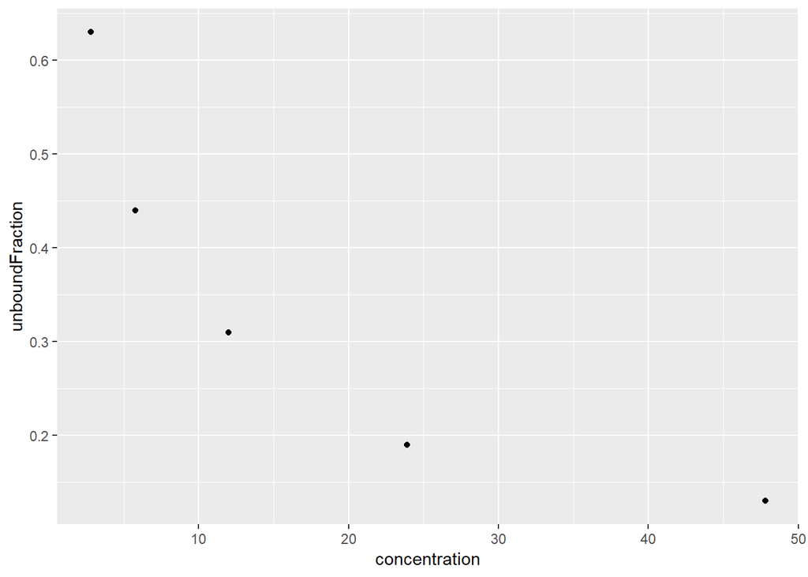

```r
#plot of liver
ggplot(data = liver,
       mapping = aes(x = concentration, y = unboundFraction))+
  geom_point()
```

### c.Exame the plot in part (b). THe relationship appears to be maximally strong, yet the correlation coefficient you calculated in (a) is not near the maximum possible value. Why?

The data does not look to be linearly related. The r value only reprsents data that are linearly related. This data looks to be exponentail decay.

### d. What steps would you take wtih these data to meet the assumptions of correlation analysis?

I would transform the data to become linear. A log transform would get this close to linear.

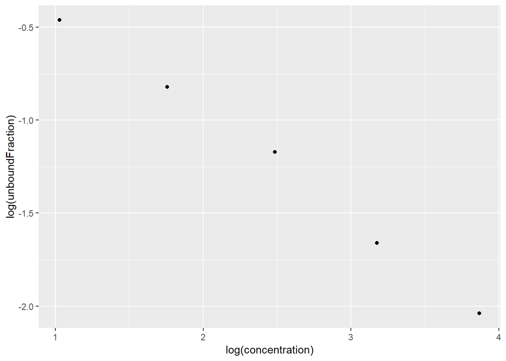

```r
#plot of log liver
ggplot(data = liver,
       mapping = aes(x = log(concentration), y = log(unboundFraction)))+
  geom_point()
```

```r
#corilation coefficient of log liver
cor(log(liver$concentration), log(liver$unboundFraction))
```

```
## [1] -0.9974872
```

# 2 Correlation SE

## Consider the following dataset

### a.Are these two variables correlated? What is the output of cor() here. What does a test show you?

```r
##get data
set.seed(20181011)
library(mnormt)
mat <- rmnorm(10, varcov = matrix(c(1,0.3, 0.3, 1), ncol=2)) %>%
  round(2) %>%
  as.data.frame %>%
  rename(cats = "V1", happiness_score = "V2")

head(mat)
```

```
##    cats happiness_score
## 1 -0.30           -0.57
## 2  0.42           -0.10
## 3  0.85           -0.04
## 4 -0.45           -0.29
## 5  0.22            0.42
## 6 -0.12           -0.92
```

```r
#correlation coeficent
cor_mat <- cor.test(mat$cats, mat$happiness_score)
```

The correlation is 0.676. This shows us that the 2 varibles relate to eachother in a linear way. i.e one varible can explain the variability in the other.

### b.What is the SE of the correlation based on the info from cor.test()

```r
cor.test(mat$cats, mat$happiness_score) %>% broom::glance()
```

```
## # A tibble: 1 x 8
##   estimate statistic p.value parameter conf.low conf.high method
##      <dbl>     <dbl>   <dbl>     <int>    <dbl>     <dbl> <chr>
## 1    0.676      2.59  0.0319         8   0.0805     0.916 Pears~
## # ... with 1 more variable: alternative <chr>
```

```r
SE<- sqrt((1-(cor_mat$estimate^2))/(length(mat$cats-2)))

SE
```

```
##       cor
## 0.2330654
```

the low confidence interval is 0.0805 and the high is 0.9158. Using the equation above, we get the standard error. In this case it is 0.233.

### c.Now, what is the SE via simulation? To do this, you’ll need to use cor() and get the relevant parameter from the output (remember - you get a matrix back, so, what’s the right index!), replicate(), and sample() or dplyr::sample_n() with replace=TRUE to get, let’s say, 1000 correlations. How does this compare to your value above?

```r
# SE simulation with 1000 correlations index is 1,2
SE_sim <- replicate(1000, cor(sample_n(mat, nrow(mat),replace= TRUE)) [1,2])

#this value should compare to the above
mean(SE_sim)
```

```
## [1] 0.6731567
```

```r
sd(SE_sim) # this is the standard error of the estimate
```

```
## [1] 0.1524226
```

# 3 W&S chapter 17

## 19

### a. Draw a scatter plot of these data. Which variable should be the explanatory variable (X), and which should be the responce variable(Y)?

```r
plants <- read_csv("../Data/chap17q19GrasslandNutrientsPlantSpecies.csv")
head(plants)
```

```
## # A tibble: 6 x 2
##   nutrients species
##       <int>   <int>
## 1         0      36
## 2         0      36
## 3         0      32
## 4         1      34
## 5         2      33
## 6         3      30
```

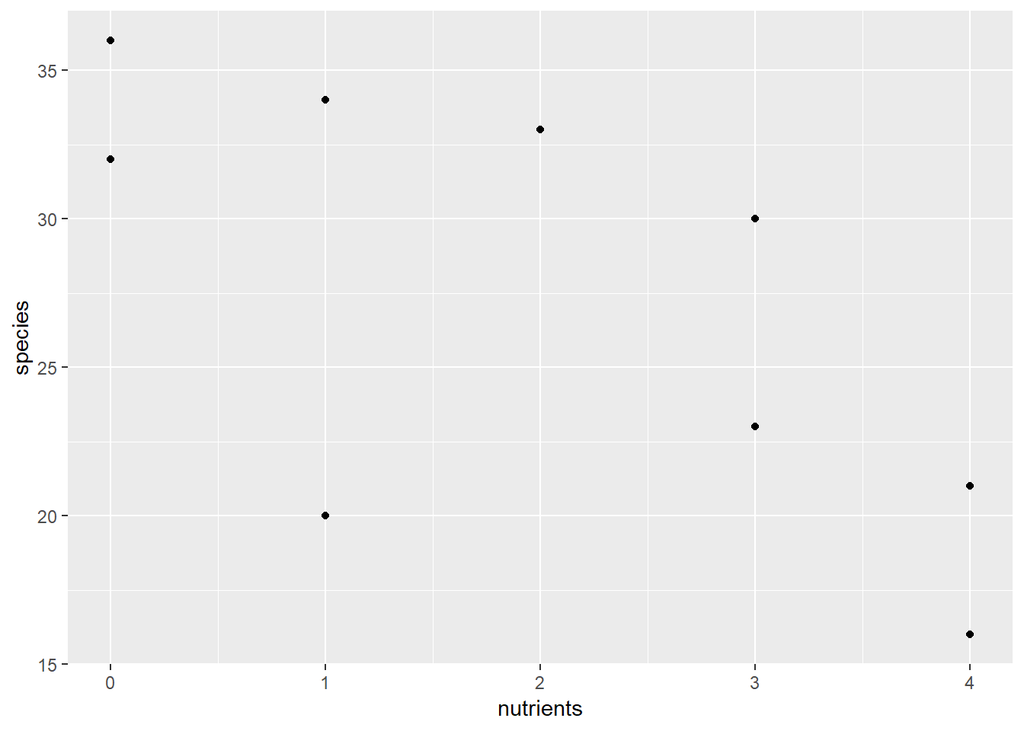

```r
plant_plot <- ggplot(data = plants,
       mapping = aes(x = nutrients, y = species))+
  geom_point()

plant_plot
```

X should be the independant variable in this case nutrients. The y variable should be the dependant variable in this case number of species.

### b. What is the rate of change in the number of plant species supported per nutrient type added? provide a standard error for your estimate.

```r
plant_mod <- lm(species ~ nutrients, data = plants)

summary(plant_mod)
```

```
##
## Call:
## lm(formula = species ~ nutrients, data = plants)
##
## Residuals:
##     Min      1Q  Median      3Q     Max
## -10.771  -1.856   1.068   2.894   5.907
##
## Coefficients:
##             Estimate Std. Error t value Pr(>|t|)
## (Intercept)   34.110      2.599   13.12 1.08e-06 ***
## nutrients     -3.339      1.098   -3.04   0.0161 *
## ---
## Signif. codes:  0 '***' 0.001 '**' 0.01 '*' 0.05 '.' 0.1 ' ' 1
##
## Residual standard error: 5.336 on 8 degrees of freedom
## Multiple R-squared:  0.536,  Adjusted R-squared:  0.478
## F-statistic: 9.241 on 1 and 8 DF,  p-value: 0.01607
```

### c. Add the least squares regression line to your scatter plot. What fraction of the variation in the number of plant species is “explained” by the number of nutrients added?

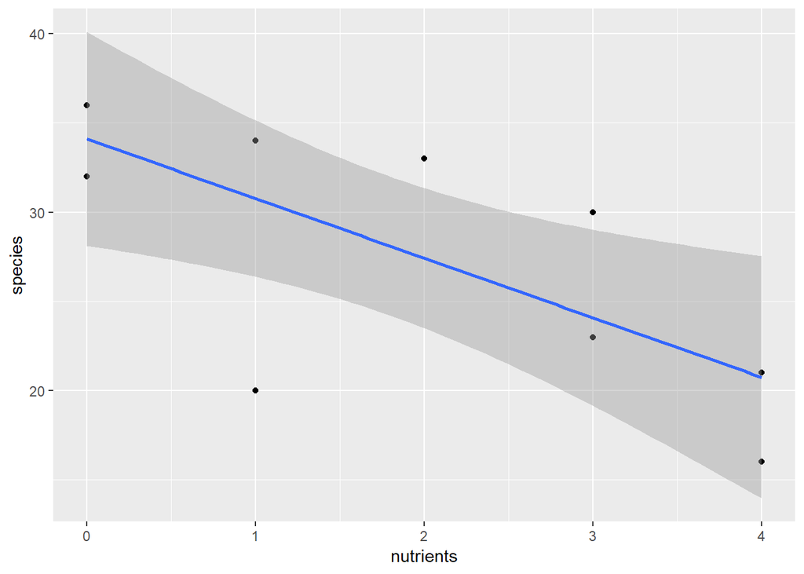

```r
plant_plot +
   stat_smooth(method=lm, formula=y~x)
```

The R squared is 0.536 and this shows what proportion of the varability can be explained by the relationship between nutrients and species.

### d. Test the null hypothesis of no treatment effect on the number of plant species.

```r
anova(plant_mod) %>% broom::tidy()
```

```
## # A tibble: 2 x 6
##   term         df sumsq meansq statistic p.value
##   <chr>     <int> <dbl>  <dbl>     <dbl>   <dbl>
## 1 nutrients     1  263.  263.       9.24  0.0161
## 2 Residuals     8  228.   28.5     NA    NA
```

The p value is less than 0.05 therfore we can reject the null hypothesis.

## 30

### a. What is the appoximate slope of the regression line?

```r
teeth <- read_csv("../Data/chap17q30NuclearTeeth.csv")
teeth
```

```
## # A tibble: 16 x 2
##    dateOfBirth deltaC14
##          <dbl>    <int>
##  1       1986.       89
##  2       1984.      109
##  3       1990.       91
##  4       1988.      127
##  5       1990.       99
##  6       1984.      110
##  7       1984.      123
##  8       1990.      105
##  9       1964.      622
## 10       1972.      262
## 11       1964.      471
## 12       1990.      112
## 13       1975       285
## 14       1970.      439
## 15       1973.      363
## 16       1972.      391
```

```r
teeth_mod <- lm(deltaC14 ~ dateOfBirth, data = teeth)

summary(teeth_mod)
```

```
##
## Call:
## lm(formula = deltaC14 ~ dateOfBirth, data = teeth)
##
## Residuals:
##     Min      1Q  Median      3Q     Max
## -107.81  -46.84   14.73   37.35  115.17
##
## Coefficients:
##             Estimate Std. Error t value Pr(>|t|)
## (Intercept) 33318.21    3108.36   10.72 3.93e-08 ***
## dateOfBirth   -16.71       1.57  -10.64 4.30e-08 ***
## ---
## Signif. codes:  0 '***' 0.001 '**' 0.01 '*' 0.05 '.' 0.1 ' ' 1
##
## Residual standard error: 58.75 on 14 degrees of freedom
## Multiple R-squared:   0.89,  Adjusted R-squared:  0.8821
## F-statistic: 113.3 on 1 and 14 DF,  p-value: 4.296e-08
```

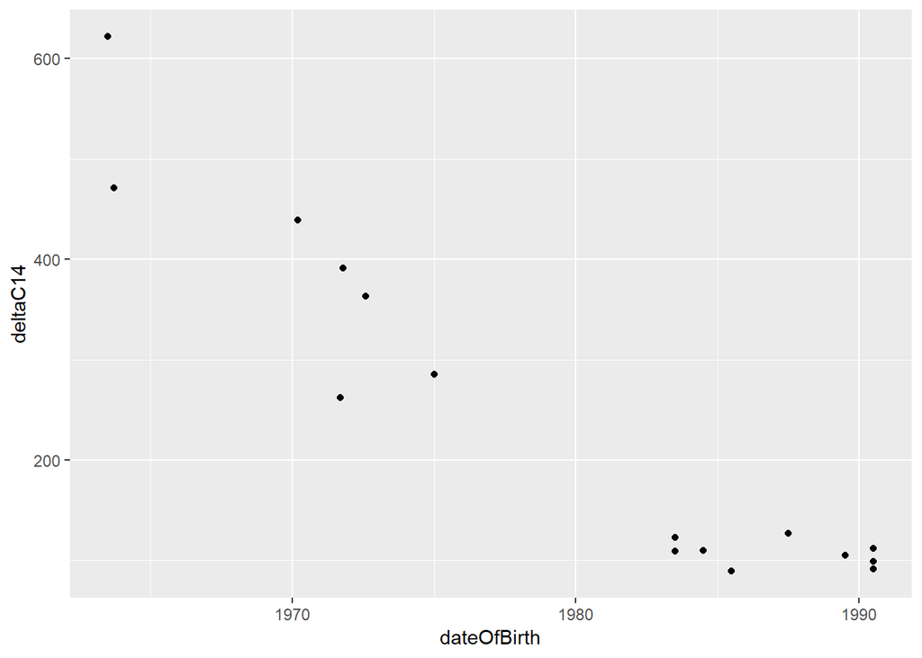

```r
ggplot(data = teeth,
       mapping = (aes(x= dateOfBirth, y = deltaC14)))+
  geom_point()
```

The slope of the regression line is -16.71.

### b. Which pair of lines shows the confidence bands? What do these confidence bands tell us?

The confidence bands are the narrower bands. They tell us how how close we get to predicting y for each value of x. It only has internal variability.

### c. Which pair of lines shows the prediction interval? What does this prediction interval tell us?

The prediction interval is the wider lines. This takes into acount standard deviation and allows us to make a predictioin about y.

## 31

### a. Calculate a regression line that best describes the relationship between year of painting and portion size. What is the trend? How rapidly has portion size changed in paintings?

```r
Jesus <- read_csv("../Data/chap17q31LastSupperPortionSize.csv")
Jesus
```

```
## # A tibble: 33 x 2
##    portionSize  year
##          <dbl> <int>
##  1        3.08   999
##  2        2.7   1004
##  3        2.14  1050
##  4        2.91  1098
##  5        3.69  1314
##  6        4.41  1314
##  7        3.51  1350
##  8        2.44  1309
##  9        3.21  1398
## 10        2.78  1400
## # ... with 23 more rows
```

```r
Jesus_mod <- lm(portionSize ~ year, data = Jesus)
summary(Jesus_mod)
```

```
##
## Call:
## lm(formula = portionSize ~ year, data = Jesus)
##
## Residuals:
##     Min      1Q  Median      3Q     Max
## -1.8448 -0.7394 -0.1865  0.9233  1.7290
##
## Coefficients:
##               Estimate Std. Error t value Pr(>|t|)
## (Intercept) -1.1688424  1.3954709  -0.838  0.40867
## year         0.0033289  0.0009705   3.430  0.00173 **
## ---
## Signif. codes:  0 '***' 0.001 '**' 0.01 '*' 0.05 '.' 0.1 ' ' 1
##
## Residual standard error: 1.001 on 31 degrees of freedom
## Multiple R-squared:  0.2751, Adjusted R-squared:  0.2517
## F-statistic: 11.77 on 1 and 31 DF,  p-value: 0.001727
```

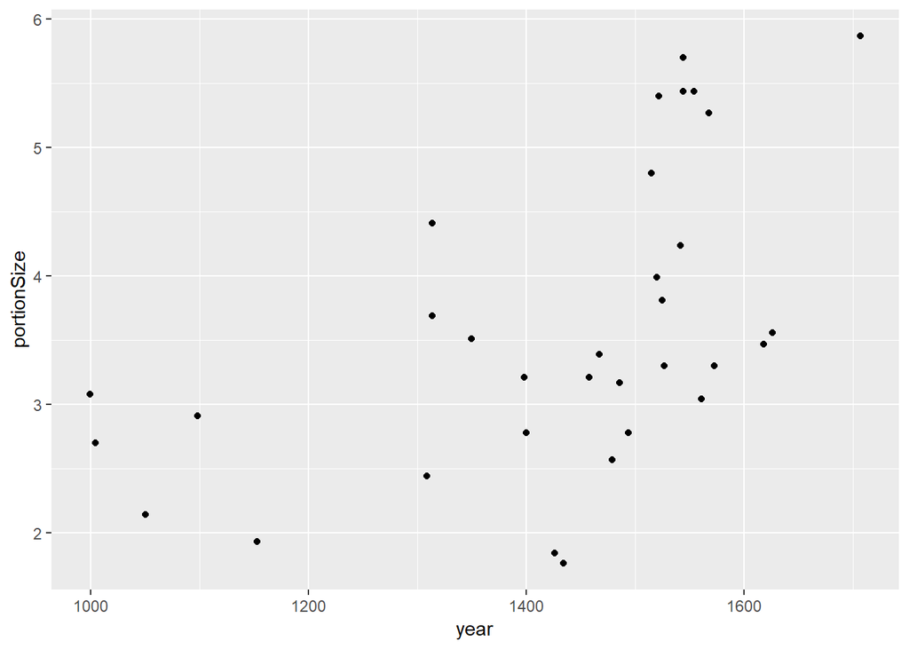

```r
ggplot(data = Jesus,
       mapping = aes(x = year, y = portionSize))+
  geom_point()
```

```r
Jesus_mod
```

```
##
## Call:
## lm(formula = portionSize ~ year, data = Jesus)
##
## Coefficients:
## (Intercept)         year
##   -1.168842     0.003329
```

The regression line has a slope of 0.003329 and an intercept of -1.1688. The line would be portionSIze = 0.003329*year - 1.1688.portiaons size is increasing over time.

### b. What is the most-plausible range of values for the slope of this relationship? calculate a 95% confidence interval.

```r
confint(Jesus_mod)
```

```
##                    2.5 %      97.5 %
## (Intercept) -4.014924002 1.677239200
## year         0.001349556 0.005308266
```

### c. Test for a change in relative portion size painted in these works of art with the year in which they were painted.

```r
anova(Jesus_mod)
```

```
## Analysis of Variance Table
##
## Response: portionSize
##           Df Sum Sq Mean Sq F value   Pr(>F)
## year       1 11.782 11.7819  11.765 0.001727 **
## Residuals 31 31.043  1.0014
## ---
## Signif. codes:  0 '***' 0.001 '**' 0.01 '*' 0.05 '.' 0.1 ' ' 1
```

### d. Draw a residual plot of these data and examine it carefully. Can you see any cause for concern about using a linear regression? Suggest an approach that could be tried to address the problem.

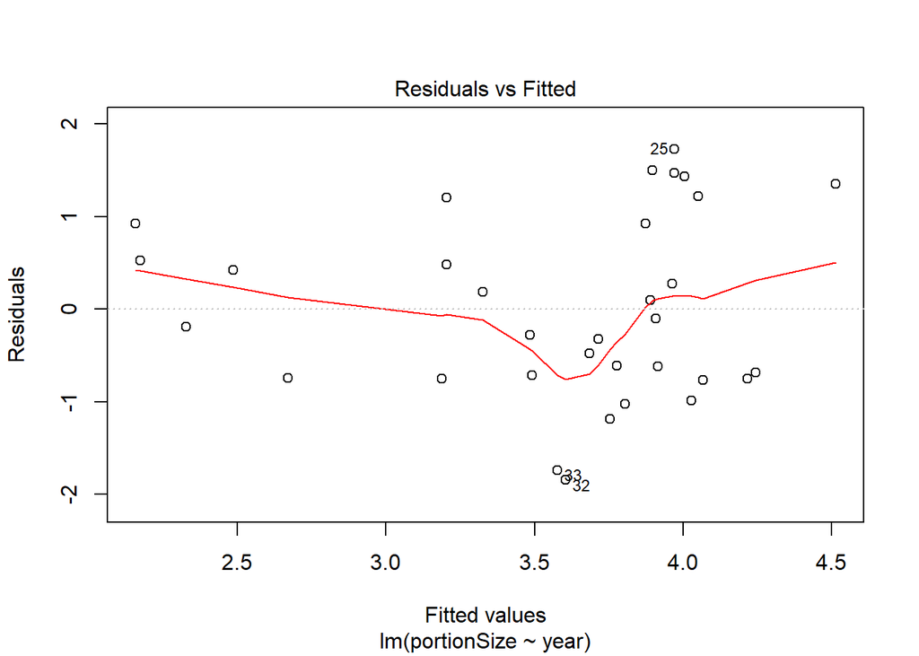

```r
plot(Jesus_mod, which = 1)
```

# 4 Intervals and simulations

## a.Using geom_abline() make a plot that has the following layers and shows that these simulated lines match up well with the fit CI. 1) the data, 2) the lm fit with a CI, and 3) simulated lines. You might have to much around to make it look as good as possible.

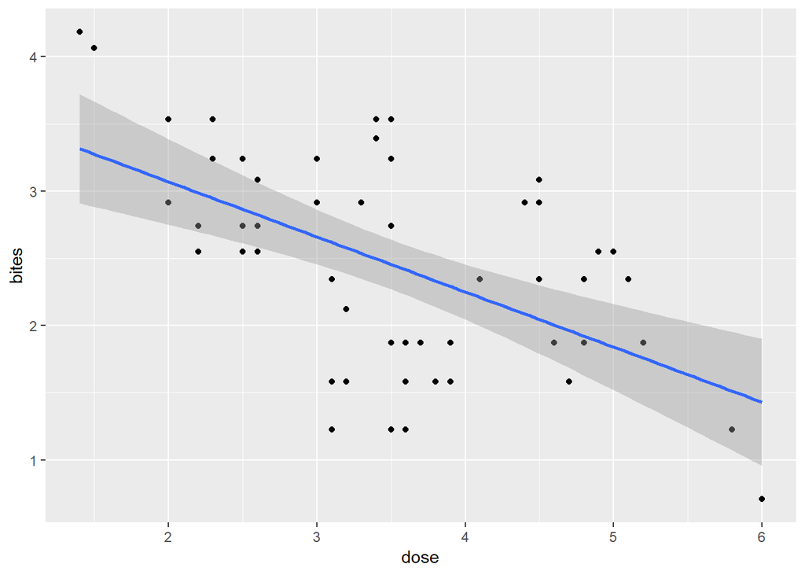

```r
deet <- read.csv("../data/17q24DEETMosquiteBites.csv")
ggplot(deet, aes(dose, bites)) +
  geom_point() +
  stat_smooth(method=lm)
```

```r
deet_mod <- lm(bites ~ dose, data = deet)

vcov(deet_mod)
```

```
##             (Intercept)         dose
## (Intercept)  0.09929780 -0.025986850
## dose        -0.02598685  0.007437073
```

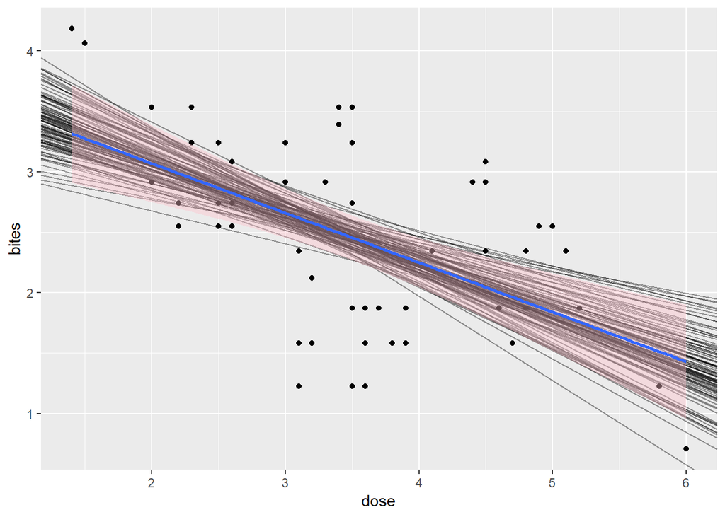

```r
coef_sim <- rmnorm(100, mean = coef(deet_mod), varcov = vcov(deet_mod)) %>%
  as.data.frame


ggplot(data = deet,
       mapping = aes(x = dose, y = bites))+
  geom_point()+
  geom_abline(data = coef_sim,
              mapping = aes(slope = dose, intercept =`(Intercept)`), alpha = 0.4) +
  stat_smooth(data = deet, method=lm, fill = "pink")
```

## b.That’s all well and good, but what about the prediction intervals? To each line, we can add some error drawn from the residual standard deviation. That residual can either be extracted from summary() or you can get the sd of residuals.

## Now, visualize the simulated prediction interval around the fit versus the calculated prediction interval around the fit via predict. +1 extra credit for a clever visualization of all elements on one figure - however you would like

```r
coef_sim <- coef_sim %>%
  mutate(error = rnorm(n(), 0, sd(deet_mod$residuals)))


pred_frame <- predict(deet_mod, interval="prediction") %>% cbind(deet)
```

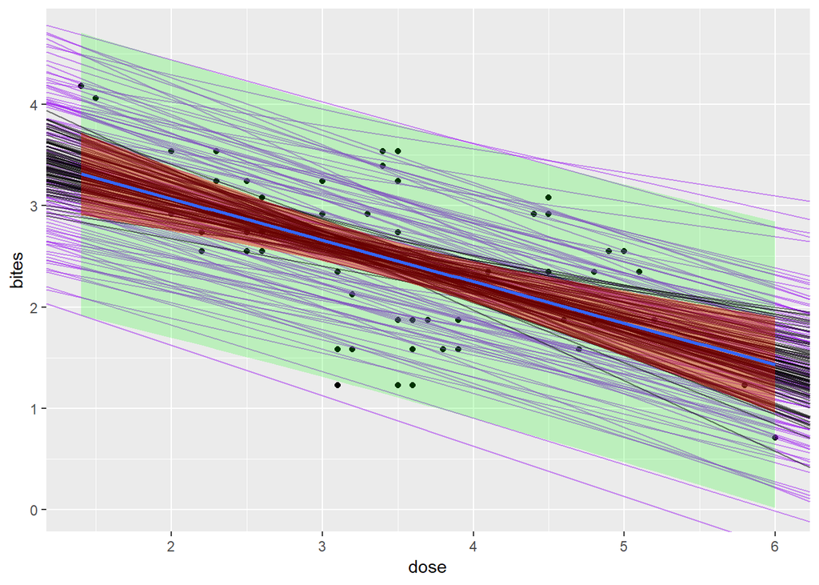

```r
ggplot(deet, aes(dose, bites)) +
  geom_point() +
  geom_abline(data = coef_sim, aes(slope = dose, intercept = error+`(Intercept)`), alpha = 0.5, color = "purple") +
  geom_ribbon(data = pred_frame, aes(ymin = lwr, ymax = upr), fill = "green", alpha = 0.2) +
  geom_abline(data = coef_sim, aes(slope = dose, intercept = `(Intercept)`), alpha = 0.5) +
  stat_smooth(data = deet, method=lm, fill = "red")
```